# Risk Factor Analysis

## Outcome Variable

**Outcome Variable:** wasted

## Predictor Variables

**Intervention Variable:** nrooms

**Adjustment Set:**

- arm
- sex
- W_mage
- meducyrs
- feducyrs
- hhwealth_quart
- hfoodsec
- W_mhtcm
- W_nchldlt5
- W_parity
- impfloor
- impsan
- safeh20
- delta_W_mage
- delta_meducyrs
- delta_feducyrs
- delta_hhwealth_quart
- delta_hfoodsec
- delta_W_mhtcm
- delta_W_nchldlt5
- delta_W_parity
- delta_impfloor
- delta_impsan
- delta_safeh20

## Stratifying Variables

The analysis was stratified on these variable(s):

- agecat
- studyid
- country

## Data Summary

| agecat | studyid | country | nrooms | wasted | n_cell | n |
| --- | --- | --- | --- | --- | --- | --- |
| Birth | ki0047075b-MAL-ED | BANGLADESH | 4+ | 0 | 11 | 222 |
| Birth | ki0047075b-MAL-ED | BANGLADESH | 4+ | 1 | 1 | 222 |
| Birth | ki0047075b-MAL-ED | BANGLADESH | 1 | 0 | 106 | 222 |
| Birth | ki0047075b-MAL-ED | BANGLADESH | 1 | 1 | 29 | 222 |
| Birth | ki0047075b-MAL-ED | BANGLADESH | 2 | 0 | 43 | 222 |
| Birth | ki0047075b-MAL-ED | BANGLADESH | 2 | 1 | 4 | 222 |
| Birth | ki0047075b-MAL-ED | BANGLADESH | 3 | 0 | 24 | 222 |
| Birth | ki0047075b-MAL-ED | BANGLADESH | 3 | 1 | 4 | 222 |
| Birth | ki0047075b-MAL-ED | BRAZIL | 4+ | 0 | 95 | 167 |
| Birth | ki0047075b-MAL-ED | BRAZIL | 4+ | 1 | 4 | 167 |
| Birth | ki0047075b-MAL-ED | BRAZIL | 1 | 0 | 3 | 167 |
| Birth | ki0047075b-MAL-ED | BRAZIL | 1 | 1 | 0 | 167 |
| Birth | ki0047075b-MAL-ED | BRAZIL | 2 | 0 | 17 | 167 |
| Birth | ki0047075b-MAL-ED | BRAZIL | 2 | 1 | 2 | 167 |
| Birth | ki0047075b-MAL-ED | BRAZIL | 3 | 0 | 46 | 167 |
| Birth | ki0047075b-MAL-ED | BRAZIL | 3 | 1 | 0 | 167 |
| Birth | ki0047075b-MAL-ED | INDIA | 4+ | 0 | 19 | 188 |
| Birth | ki0047075b-MAL-ED | INDIA | 4+ | 1 | 3 | 188 |
| Birth | ki0047075b-MAL-ED | INDIA | 1 | 0 | 57 | 188 |
| Birth | ki0047075b-MAL-ED | INDIA | 1 | 1 | 11 | 188 |
| Birth | ki0047075b-MAL-ED | INDIA | 2 | 0 | 57 | 188 |
| Birth | ki0047075b-MAL-ED | INDIA | 2 | 1 | 9 | 188 |
| Birth | ki0047075b-MAL-ED | INDIA | 3 | 0 | 25 | 188 |
| Birth | ki0047075b-MAL-ED | INDIA | 3 | 1 | 7 | 188 |
| Birth | ki0047075b-MAL-ED | NEPAL | 4+ | 0 | 79 | 166 |
| Birth | ki0047075b-MAL-ED | NEPAL | 4+ | 1 | 15 | 166 |
| Birth | ki0047075b-MAL-ED | NEPAL | 1 | 0 | 31 | 166 |
| Birth | ki0047075b-MAL-ED | NEPAL | 1 | 1 | 3 | 166 |
| Birth | ki0047075b-MAL-ED | NEPAL | 2 | 0 | 21 | 166 |
| Birth | ki0047075b-MAL-ED | NEPAL | 2 | 1 | 0 | 166 |

[output cut: 338 more lines]

The following strata were considered:

- agecat: 24 months, studyid: ki0047075b-MAL-ED, country: BANGLADESH
- agecat: 24 months, studyid: ki0047075b-MAL-ED, country: BRAZIL
- agecat: 24 months, studyid: ki0047075b-MAL-ED, country: INDIA
- agecat: 24 months, studyid: ki0047075b-MAL-ED, country: NEPAL
- agecat: 24 months, studyid: ki0047075b-MAL-ED, country: PERU
- agecat: 24 months, studyid: ki0047075b-MAL-ED, country: SOUTH AFRICA
- agecat: 24 months, studyid: ki0047075b-MAL-ED, country: TANZANIA, UNITED REPUBLIC OF
- agecat: 24 months, studyid: ki1000108-CMC-V-BCS-2002, country: INDIA
- agecat: 24 months, studyid: ki1000108-IRC, country: INDIA
- agecat: 24 months, studyid: ki1017093b-PROVIDE, country: BANGLADESH
- agecat: 24 months, studyid: ki1017093c-NIH-Crypto, country: BANGLADESH
- agecat: 24 months, studyid: ki1113344-GMS-Nepal, country: NEPAL
- agecat: 24 months, studyid: ki1114097-CONTENT, country: PERU
- agecat: 24 months, studyid: ki1135781-COHORTS, country: INDIA
- agecat: 24 months, studyid: kiGH5241-JiVitA-3, country: BANGLADESH
- agecat: 24 months, studyid: kiGH5241-JiVitA-4, country: BANGLADESH
- agecat: 6 months, studyid: ki0047075b-MAL-ED, country: BANGLADESH
- agecat: 6 months, studyid: ki0047075b-MAL-ED, country: BRAZIL
- agecat: 6 months, studyid: ki0047075b-MAL-ED, country: INDIA
- agecat: 6 months, studyid: ki0047075b-MAL-ED, country: NEPAL
- agecat: 6 months, studyid: ki0047075b-MAL-ED, country: PERU
- agecat: 6 months, studyid: ki0047075b-MAL-ED, country: SOUTH AFRICA
- agecat: 6 months, studyid: ki0047075b-MAL-ED, country: TANZANIA, UNITED REPUBLIC OF
- agecat: 6 months, studyid: ki1000108-CMC-V-BCS-2002, country: INDIA
- agecat: 6 months, studyid: ki1000108-IRC, country: INDIA
- agecat: 6 months, studyid: ki1017093b-PROVIDE, country: BANGLADESH
- agecat: 6 months, studyid: ki1017093c-NIH-Crypto, country: BANGLADESH
- agecat: 6 months, studyid: ki1113344-GMS-Nepal, country: NEPAL
- agecat: 6 months, studyid: ki1114097-CONTENT, country: PERU
- agecat: 6 months, studyid: ki1135781-COHORTS, country: INDIA
- agecat: 6 months, studyid: kiGH5241-JiVitA-3, country: BANGLADESH
- agecat: 6 months, studyid: kiGH5241-JiVitA-4, country: BANGLADESH
- agecat: Birth, studyid: ki0047075b-MAL-ED, country: BANGLADESH
- agecat: Birth, studyid: ki0047075b-MAL-ED, country: BRAZIL
- agecat: Birth, studyid: ki0047075b-MAL-ED, country: INDIA
- agecat: Birth, studyid: ki0047075b-MAL-ED, country: NEPAL
- agecat: Birth, studyid: ki0047075b-MAL-ED, country: PERU
- agecat: Birth, studyid: ki0047075b-MAL-ED, country: SOUTH AFRICA
- agecat: Birth, studyid: ki0047075b-MAL-ED, country: TANZANIA, UNITED REPUBLIC OF
- agecat: Birth, studyid: ki1000108-CMC-V-BCS-2002, country: INDIA
- agecat: Birth, studyid: ki1000108-IRC, country: INDIA
- agecat: Birth, studyid: ki1017093c-NIH-Crypto, country: BANGLADESH
- agecat: Birth, studyid: ki1114097-CONTENT, country: PERU
- agecat: Birth, studyid: ki1135781-COHORTS, country: INDIA
- agecat: Birth, studyid: kiGH5241-JiVitA-3, country: BANGLADESH
- agecat: Birth, studyid: kiGH5241-JiVitA-4, country: BANGLADESH

### Dropped Strata

Some strata were dropped due to rare outcomes:

- agecat: Birth, studyid: ki0047075b-MAL-ED, country: BANGLADESH
- agecat: Birth, studyid: ki0047075b-MAL-ED, country: BRAZIL
- agecat: Birth, studyid: ki0047075b-MAL-ED, country: INDIA
- agecat: Birth, studyid: ki0047075b-MAL-ED, country: NEPAL
- agecat: Birth, studyid: ki0047075b-MAL-ED, country: PERU
- agecat: Birth, studyid: ki0047075b-MAL-ED, country: SOUTH AFRICA
- agecat: Birth, studyid: ki0047075b-MAL-ED, country: TANZANIA, UNITED REPUBLIC OF
- agecat: Birth, studyid: ki1000108-CMC-V-BCS-2002, country: INDIA
- agecat: Birth, studyid: ki1017093c-NIH-Crypto, country: BANGLADESH
- agecat: Birth, studyid: ki1114097-CONTENT, country: PERU
- agecat: Birth, studyid: kiGH5241-JiVitA-4, country: BANGLADESH
- agecat: 6 months, studyid: ki0047075b-MAL-ED, country: BANGLADESH
- agecat: 6 months, studyid: ki0047075b-MAL-ED, country: BRAZIL
- agecat: 6 months, studyid: ki0047075b-MAL-ED, country: INDIA
- agecat: 6 months, studyid: ki0047075b-MAL-ED, country: NEPAL
- agecat: 6 months, studyid: ki0047075b-MAL-ED, country: PERU
- agecat: 6 months, studyid: ki0047075b-MAL-ED, country: SOUTH AFRICA
- agecat: 6 months, studyid: ki0047075b-MAL-ED, country: TANZANIA, UNITED REPUBLIC OF
- agecat: 6 months, studyid: ki1000108-CMC-V-BCS-2002, country: INDIA
- agecat: 6 months, studyid: ki1000108-IRC, country: INDIA
- agecat: 6 months, studyid: ki1017093b-PROVIDE, country: BANGLADESH
- agecat: 6 months, studyid: ki1017093c-NIH-Crypto, country: BANGLADESH
- agecat: 6 months, studyid: ki1113344-GMS-Nepal, country: NEPAL
- agecat: 6 months, studyid: ki1114097-CONTENT, country: PERU
- agecat: 6 months, studyid: ki1135781-COHORTS, country: INDIA
- agecat: 24 months, studyid: ki0047075b-MAL-ED, country: BANGLADESH
- agecat: 24 months, studyid: ki0047075b-MAL-ED, country: BRAZIL
- agecat: 24 months, studyid: ki0047075b-MAL-ED, country: INDIA
- agecat: 24 months, studyid: ki0047075b-MAL-ED, country: NEPAL
- agecat: 24 months, studyid: ki0047075b-MAL-ED, country: PERU
- agecat: 24 months, studyid: ki0047075b-MAL-ED, country: SOUTH AFRICA
- agecat: 24 months, studyid: ki0047075b-MAL-ED, country: TANZANIA, UNITED REPUBLIC OF
- agecat: 24 months, studyid: ki1000108-CMC-V-BCS-2002, country: INDIA
- agecat: 24 months, studyid: ki1000108-IRC, country: INDIA
- agecat: 24 months, studyid: ki1017093b-PROVIDE, country: BANGLADESH
- agecat: 24 months, studyid: ki1017093c-NIH-Crypto, country: BANGLADESH
- agecat: 24 months, studyid: ki1113344-GMS-Nepal, country: NEPAL
- agecat: 24 months, studyid: ki1114097-CONTENT, country: PERU
- agecat: 24 months, studyid: ki1135781-COHORTS, country: INDIA

## Methods Detail

We’re interested in the causal parameters $E[Y_a]$ for all values of $a \in \mathcal{A}$. These parameters represent the mean outcome if, possibly contrary to fact, we intervened to set all units to have $A=a$. Under the randomization and positivity assumptions, these are identified by the statistical parameters $\psi_a=E_W[E_{Y|A,W}(Y|A=a,W)]$. In addition, we’re interested in the mean of $Y$, $E[Y]$ under no intervention (the observed mean). We will estimate these parameters by using SuperLearner to fit the relevant likelihood factors – $E_{Y|A,W}(Y|A=a,W)$ and $p(A=a|W)$, and then updating our likelihood fit using a joint TMLE.

For unadjusted analyses ($W=\{\}$), initial likelihoods were estimated using Lrnr_glm to estimate the simple $E(Y|A)$ and Lrnr_mean to estimate $p(A)$. For adjusted analyses, a small library containing Lrnr_glmnet, Lrnr_xgboost, and Lrnr_mean was used.

Having estimated these parameters, we will then use the delta method to estimate relative risks and attributable risks relative to a prespecified baseline level of $A$.

# Results Detail

## Results Plots

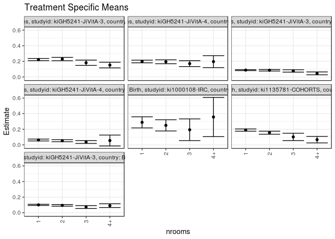

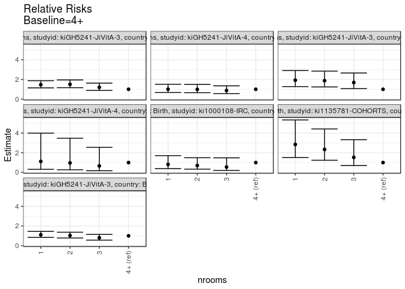

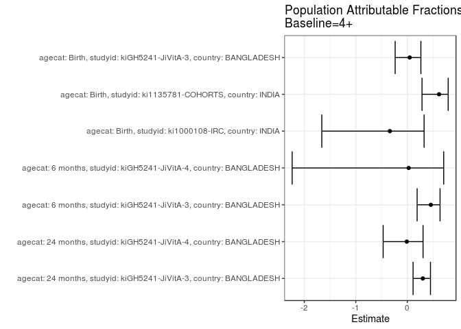

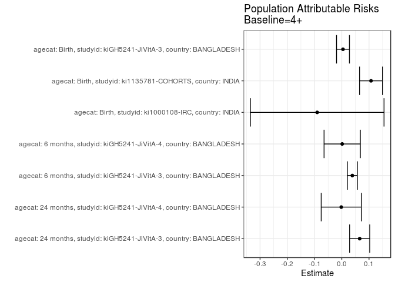

## Results Table

### Parameter: TSM

| agecat | studyid | country | intervention_level | baseline_level | estimate | ci_lower | ci_upper |
| --- | --- | --- | --- | --- | --- | --- | --- |
| Birth | ki1000108-IRC | INDIA | 4+ | NA | 0.3571429 | 0.1057806 | 0.6085051 |
| Birth | ki1000108-IRC | INDIA | 1 | NA | 0.2884615 | 0.2172637 | 0.3596594 |
| Birth | ki1000108-IRC | INDIA | 2 | NA | 0.2500000 | 0.1781673 | 0.3218327 |
| Birth | ki1000108-IRC | INDIA | 3 | NA | 0.1935484 | 0.0542683 | 0.3328284 |
| Birth | ki1135781-COHORTS | INDIA | 4+ | NA | 0.0666667 | 0.0250085 | 0.1083249 |
| Birth | ki1135781-COHORTS | INDIA | 1 | NA | 0.1896492 | 0.1753277 | 0.2039707 |
| Birth | ki1135781-COHORTS | INDIA | 2 | NA | 0.1558735 | 0.1363621 | 0.1753849 |
| Birth | ki1135781-COHORTS | INDIA | 3 | NA | 0.1019108 | 0.0545830 | 0.1492387 |
| Birth | kiGH5241-JiVitA-3 | BANGLADESH | 4+ | NA | 0.0914932 | 0.0674157 | 0.1155708 |
| Birth | kiGH5241-JiVitA-3 | BANGLADESH | 1 | NA | 0.1012239 | 0.0938731 | 0.1085746 |
| Birth | kiGH5241-JiVitA-3 | BANGLADESH | 2 | NA | 0.0948019 | 0.0840562 | 0.1055477 |
| Birth | kiGH5241-JiVitA-3 | BANGLADESH | 3 | NA | 0.0736033 | 0.0555820 | 0.0916246 |
| 6 months | kiGH5241-JiVitA-3 | BANGLADESH | 4+ | NA | 0.0458065 | 0.0272619 | 0.0643511 |
| 6 months | kiGH5241-JiVitA-3 | BANGLADESH | 1 | NA | 0.0881191 | 0.0817288 | 0.0945094 |
| 6 months | kiGH5241-JiVitA-3 | BANGLADESH | 2 | NA | 0.0860678 | 0.0762105 | 0.0959250 |
| 6 months | kiGH5241-JiVitA-3 | BANGLADESH | 3 | NA | 0.0772416 | 0.0623096 | 0.0921736 |
| 6 months | kiGH5241-JiVitA-4 | BANGLADESH | 4+ | NA | 0.0554665 | -0.0143338 | 0.1252667 |
| 6 months | kiGH5241-JiVitA-4 | BANGLADESH | 1 | NA | 0.0620216 | 0.0501106 | 0.0739327 |
| 6 months | kiGH5241-JiVitA-4 | BANGLADESH | 2 | NA | 0.0534966 | 0.0402228 | 0.0667705 |
| 6 months | kiGH5241-JiVitA-4 | BANGLADESH | 3 | NA | 0.0366568 | 0.0187440 | 0.0545695 |
| 24 months | kiGH5241-JiVitA-3 | BANGLADESH | 4+ | NA | 0.1521933 | 0.1158749 | 0.1885117 |
| 24 months | kiGH5241-JiVitA-3 | BANGLADESH | 1 | NA | 0.2227964 | 0.2091457 | 0.2364471 |
| 24 months | kiGH5241-JiVitA-3 | BANGLADESH | 2 | NA | 0.2294557 | 0.2084554 | 0.2504560 |
| 24 months | kiGH5241-JiVitA-3 | BANGLADESH | 3 | NA | 0.1821125 | 0.1480096 | 0.2162154 |
| 24 months | kiGH5241-JiVitA-4 | BANGLADESH | 4+ | NA | 0.1963966 | 0.1198630 | 0.2729302 |
| 24 months | kiGH5241-JiVitA-4 | BANGLADESH | 1 | NA | 0.1982434 | 0.1809663 | 0.2155204 |
| 24 months | kiGH5241-JiVitA-4 | BANGLADESH | 2 | NA | 0.1944878 | 0.1696569 | 0.2193187 |
| 24 months | kiGH5241-JiVitA-4 | BANGLADESH | 3 | NA | 0.1708506 | 0.1330937 | 0.2086074 |

### Parameter: E(Y)

| agecat | studyid | country | intervention_level | baseline_level | estimate | ci_lower | ci_upper |
| --- | --- | --- | --- | --- | --- | --- | --- |
| Birth | ki1000108-IRC | INDIA | NA | NA | 0.2668622 | 0.2198462 | 0.3138781 |
| Birth | ki1135781-COHORTS | INDIA | NA | NA | 0.1740009 | 0.1628660 | 0.1851358 |
| Birth | kiGH5241-JiVitA-3 | BANGLADESH | NA | NA | 0.0959454 | 0.0907405 | 0.1011503 |
| 6 months | kiGH5241-JiVitA-3 | BANGLADESH | NA | NA | 0.0844810 | 0.0796719 | 0.0892901 |
| 6 months | kiGH5241-JiVitA-4 | BANGLADESH | NA | NA | 0.0569712 | 0.0481278 | 0.0658146 |
| 24 months | kiGH5241-JiVitA-3 | BANGLADESH | NA | NA | 0.2179025 | 0.2080266 | 0.2277783 |
| 24 months | kiGH5241-JiVitA-4 | BANGLADESH | NA | NA | 0.1945032 | 0.1812962 | 0.2077102 |

### Parameter: RR

| agecat | studyid | country | intervention_level | baseline_level | estimate | ci_lower | ci_upper |
| --- | --- | --- | --- | --- | --- | --- | --- |
| Birth | ki1000108-IRC | INDIA | 4+ | 4+ | 1.0000000 | 1.0000000 | 1.000000 |
| Birth | ki1000108-IRC | INDIA | 1 | 4+ | 0.8076923 | 0.3831181 | 1.702783 |
| Birth | ki1000108-IRC | INDIA | 2 | 4+ | 0.7000000 | 0.3272990 | 1.497102 |
| Birth | ki1000108-IRC | INDIA | 3 | 4+ | 0.5419355 | 0.1980599 | 1.482855 |
| Birth | ki1135781-COHORTS | INDIA | 4+ | 4+ | 1.0000000 | 1.0000000 | 1.000000 |
| Birth | ki1135781-COHORTS | INDIA | 1 | 4+ | 2.8447378 | 1.5159635 | 5.338211 |
| Birth | ki1135781-COHORTS | INDIA | 2 | 4+ | 2.3381024 | 1.2362126 | 4.422154 |
| Birth | ki1135781-COHORTS | INDIA | 3 | 4+ | 1.5286624 | 0.7017657 | 3.329899 |
| Birth | kiGH5241-JiVitA-3 | BANGLADESH | 4+ | 4+ | 1.0000000 | 1.0000000 | 1.000000 |
| Birth | kiGH5241-JiVitA-3 | BANGLADESH | 1 | 4+ | 1.1063536 | 0.8422877 | 1.453207 |
| Birth | kiGH5241-JiVitA-3 | BANGLADESH | 2 | 4+ | 1.0361632 | 0.7810767 | 1.374557 |
| Birth | kiGH5241-JiVitA-3 | BANGLADESH | 3 | 4+ | 0.8044673 | 0.5640079 | 1.147444 |
| 6 months | kiGH5241-JiVitA-3 | BANGLADESH | 4+ | 4+ | 1.0000000 | 1.0000000 | 1.000000 |
| 6 months | kiGH5241-JiVitA-3 | BANGLADESH | 1 | 4+ | 1.9237242 | 1.2725574 | 2.908093 |
| 6 months | kiGH5241-JiVitA-3 | BANGLADESH | 2 | 4+ | 1.8789422 | 1.2383509 | 2.850907 |
| 6 months | kiGH5241-JiVitA-3 | BANGLADESH | 3 | 4+ | 1.6862590 | 1.0701935 | 2.656967 |
| 6 months | kiGH5241-JiVitA-4 | BANGLADESH | 4+ | 4+ | 1.0000000 | 1.0000000 | 1.000000 |
| 6 months | kiGH5241-JiVitA-4 | BANGLADESH | 1 | 4+ | 1.1181827 | 0.3131123 | 3.993239 |
| 6 months | kiGH5241-JiVitA-4 | BANGLADESH | 2 | 4+ | 0.9644858 | 0.2673572 | 3.479364 |
| 6 months | kiGH5241-JiVitA-4 | BANGLADESH | 3 | 4+ | 0.6608819 | 0.1709358 | 2.555140 |
| 24 months | kiGH5241-JiVitA-3 | BANGLADESH | 4+ | 4+ | 1.0000000 | 1.0000000 | 1.000000 |
| 24 months | kiGH5241-JiVitA-3 | BANGLADESH | 1 | 4+ | 1.4639042 | 1.1443516 | 1.872690 |
| 24 months | kiGH5241-JiVitA-3 | BANGLADESH | 2 | 4+ | 1.5076596 | 1.1637618 | 1.953181 |
| 24 months | kiGH5241-JiVitA-3 | BANGLADESH | 3 | 4+ | 1.1965868 | 0.8803668 | 1.626390 |
| 24 months | kiGH5241-JiVitA-4 | BANGLADESH | 4+ | 4+ | 1.0000000 | 1.0000000 | 1.000000 |
| 24 months | kiGH5241-JiVitA-4 | BANGLADESH | 1 | 4+ | 1.0094031 | 0.6760911 | 1.507038 |
| 24 months | kiGH5241-JiVitA-4 | BANGLADESH | 2 | 4+ | 0.9902808 | 0.6573929 | 1.491735 |
| 24 months | kiGH5241-JiVitA-4 | BANGLADESH | 3 | 4+ | 0.8699261 | 0.5590271 | 1.353730 |

### Parameter: PAR

| agecat | studyid | country | intervention_level | baseline_level | estimate | ci_lower | ci_upper |
| --- | --- | --- | --- | --- | --- | --- | --- |
| Birth | ki1000108-IRC | INDIA | 4+ | NA | -0.0902807 | -0.3356486 | 0.1550872 |
| Birth | ki1135781-COHORTS | INDIA | 4+ | NA | 0.1073342 | 0.0652317 | 0.1494368 |
| Birth | kiGH5241-JiVitA-3 | BANGLADESH | 4+ | NA | 0.0044522 | -0.0192597 | 0.0281641 |
| 6 months | kiGH5241-JiVitA-3 | BANGLADESH | 4+ | NA | 0.0386745 | 0.0202634 | 0.0570856 |
| 6 months | kiGH5241-JiVitA-4 | BANGLADESH | 4+ | NA | 0.0015047 | -0.0650410 | 0.0680505 |
| 24 months | kiGH5241-JiVitA-3 | BANGLADESH | 4+ | NA | 0.0657092 | 0.0287632 | 0.1026551 |
| 24 months | kiGH5241-JiVitA-4 | BANGLADESH | 4+ | NA | -0.0018935 | -0.0755143 | 0.0717274 |

### Parameter: PAF

| agecat | studyid | country | intervention_level | baseline_level | estimate | ci_lower | ci_upper |
| --- | --- | --- | --- | --- | --- | --- | --- |
| Birth | ki1000108-IRC | INDIA | 4+ | NA | -0.3383046 | -1.6601876 | 0.3267170 |
| Birth | ki1135781-COHORTS | INDIA | 4+ | NA | 0.6168602 | 0.2862315 | 0.7943365 |
| Birth | kiGH5241-JiVitA-3 | BANGLADESH | 4+ | NA | 0.0464034 | -0.2356055 | 0.2640480 |
| 6 months | kiGH5241-JiVitA-3 | BANGLADESH | 4+ | NA | 0.4577895 | 0.1912286 | 0.6364953 |
| 6 months | kiGH5241-JiVitA-4 | BANGLADESH | 4+ | NA | 0.0264123 | -2.2358603 | 0.7070724 |
| 24 months | kiGH5241-JiVitA-3 | BANGLADESH | 4+ | NA | 0.3015531 | 0.1123861 | 0.4504051 |
| 24 months | kiGH5241-JiVitA-4 | BANGLADESH | 4+ | NA | -0.0097349 | -0.4688180 | 0.3058606 |